# DJJ-003_Analyses of RoH Breast Cell

djj_003_pdm_bi_010_v1.Rmd

Prabin Dhangada Majhi

Last complied on 10 November, 2023

# Introduction

This study examined the transcriptional responses of PCB 126 in epithelial cells derived from human breast. To check the details of the study, please see [Morin et al 2022](https://doi.org/10.1016/j.ecoenv.2022.113722)

- Compare control vs PCB-treated for pts 698, 1264, 1309, 1108, 1106, 1129. Sallie would like this for a publication, so this would be the highest priority.
- Use paired design (this allows DEGs to be defined within each patient). However, with only 6 patients, this may pose a problem of degrees of freedom.
- Therefore, it may be necessary to define DEGs by simply comparing Control as a group vs the PCB-treated group.
- While it would be interesting to look at DEGs for effects of PCBs in AR vs HR, 3 patients in each would not likely be sufficient. So best to delay this.

# Libraries and reusable codes

#Data Import

### Prepare sample Information

```r
#The sampleInformation is shared in the email by Joe
#The sample information file has multiple sheets.
#We will read the excel file for sheet name
sheets <- excel_sheets("docs/RNAseq-SampleSubmission b.xls")

#The sheet name sample Information will be used
sampInf <- readxl::read_excel("docs/RNAseq-SampleSubmission b.xls",
                              sheet = sheets[[2]],
                              skip = 29)

#We will edit the sample information to make it a tibble with only relevant information
sampleInfo <- sampInf %>%
  na.omit %>%
  dplyr::select(c("Sample Number","Sample Name")) %>%
  mutate(
    sample_number = `Sample Number`,
    sample_code = str_remove_all(`Sample Name`, pattern = "[:alpha:]"),
    treatment = str_remove_all(`Sample Name`, pattern = "[:digit:]"),
    treatment = case_when(
      !str_detect(treatment, "[:alpha:]") ~ "Control",
      TRUE ~ treatment),
    sample_name = paste(sample_code, "_", treatment, sep = "")) %>%
  select(-c(`Sample Number`,`Sample Name`)) %>%
  column_to_rownames(var = "sample_name")


#view the sampleInfo
  datatable(sampleInfo)
```

|  | sample_number | sample_code | treatment |
| --- | --- | --- | --- |
| 698_DMSO | 1 | 698 | DMSO |
| 698_PCB | 2 | 698 | PCB |
| 1309_DMSO | 3 | 1309 | DMSO |
| 1309_PCB | 4 | 1309 | PCB |
| 1264_DMSO | 5 | 1264 | DMSO |
| 1264_PCB | 6 | 1264 | PCB |
| 1129_DMSO | 7 | 1129 | DMSO |
| 1129_PCB | 8 | 1129 | PCB |
| 1106_DMSO | 9 | 1106 | DMSO |
| 1106_PCB | 10 | 1106 | PCB |

[output cut: 14 more lines]

### write a function for importing rsem_results

```r
#write a function to make DESeq Object
importRsem2Deseq <- function(path, sampleInfo){
        #load libraries
        packs <- c("tximport", "DESeq2")
        lapply(packs, library, character.only = TRUE)

        #get file paths
        files <- list.files(path = path, pattern = "genes.results")
        filepaths <- paste0(path, files)

        #name the filespath with sample names
        names(filepaths) <- str_remove(files, ".genes.results")

        #read the data
        txi.rsem <- tximport(filepaths,
                             type = "rsem",
                             txIn = FALSE,
                             txOut = FALSE,)

        txi.rsem$length[txi.rsem$length == 0] <- 1
#the trascript length is zero in the data, which is set to 1 using the folliwng suggestion (https://support.bioconductor.org/p/84304/)


        #make the parameters factors
        sampleInfo$sample_code <- as.factor(sampleInfo$sample_code)
        sampleInfo$treatment <- as.factor(sampleInfo$treatment)
        #check if all rsem column names are in sampleinfo
        if(all(as.numeric(colnames(txi.rsem$counts))==sampleInfo$sample_number)){
         colnames(txi.rsem$counts) = rownames(sampleInfo)
          #make a deseq dataset
        dds <- DESeqDataSetFromTximport(txi.rsem,
                                colData = sampleInfo,
                                design = ~ treatment)

        }else{dds <- print("Incorrect sampleInfo")}

        return(dds)


}
```

### Make Sure files are correctly read

The filenames as provided by LCScience was 1-24, but they could not be sorted. So I changed the file name in terminal with script (`./../../../DJJ003_src/change_rsem_filename.sh`) and then in the above function I am changing it to a name that has tissueID_treatment each.

###Import Data

```r
dds <- importRsem2Deseq(path = "data/rsem_quant/", sampleInfo = sampleInfo)
dds <- filterLowCounts(dds)
saveRDS(dds, file = "data/DJJ03_dds")
```

# Diffential Gene expression analysis.

```r
# keey only the samples which are required for this analysis
dds1 <- dds[, -grep("Control", colnames(dds))]

dds1$treatment <- droplevels(dds1$treatment)
dds1$treatment <- relevel(dds1$treatment, "DMSO")
dds1$sample_code <- droplevels(dds1$sample_code)
saveRDS(dds1, file = "data/dds1")
#save the unpaired DE design as another dds object
dds2 <- dds1 %>% DESeq()
res2 <- results(dds2, contrast = c("treatment", "PCB", "DMSO"), alpha = 0.05)
dge2 <- getSig(res2, padj = 0.05)

#introduce paired design

dds3 <- dds1
design(dds3) <- ~ sample_code + treatment
dds3$treatment <- relevel(dds3$treatment, "DMSO")

dds3 <- DESeq(dds3)
res3.1 <- results(dds3, contrast = c("treatment", "PCB", "DMSO"), alpha = 0.05)
res3.2 <- results(dds3, name = "treatment_PCB_vs_DMSO", alpha = 0.05)
dge3.2 <- getSig(res3.2, padj = 0.05)
res3.3 <- results(dds3, name = "treatment_PCB_vs_DMSO", alpha = 0.1)
dge3.3 <- getSig(res3.3, padj = 0.1)
vsd3 <- vst(dds3, blind = FALSE)
vsd3_a <- assay(vsd3)

dge3.2geneList <- dge3.2 %>%
  as.data.frame %>%
  rownames_to_column(var = "Gene") %>%
  mutate(EnsemblID = str_split(Gene, "_") %>% map_chr(1),
         Gene = str_split(Gene, "_") %>% map_chr(2))

dge3.2geneList <- dge3.2geneList[order(dge3.2geneList$log2FoldChange, decreasing = TRUE),]
write.csv(dge3.2geneList, file = "results/DGE_HMEC_PCB_vs_DMSO_v2.csv")

datatable(dge3.2geneList)
```

|  | Gene | baseMean | log2FoldChange | lfcSE | stat | pvalue | padj | EnsemblID |
| --- | --- | --- | --- | --- | --- | --- | --- | --- |
| 77 | CYP1A1 | 711.9170430761432 | 4.985348244906193 | 0.8021184168111158 | 6.215227253758657 | 5.125042218643433e-10 | 9.579436055532953e-07 | ENSG00000140465.14 |
| 36 | IL1A | 67.66912459726869 | 4.269589881412751 | 0.7661640940858214 | 5.572683338165538 | 2.508452808689943e-08 | 2.051287284306201e-05 | ENSG00000115008.6 |
| 31 | ALDH3A1 | 23.11133481266028 | 2.875449351081674 | 0.5658308914413187 | 5.081817544031848 | 3.738404153909372e-07 | 0.0001746902855348222 | ENSG00000108602.18 |
| 71 | CYP1B1 | 1955.99837374655 | 2.874580490668226 | 0.1860850379927027 | 15.4476712457718 | 7.821875733240112e-54 | 1.023414220937136e-49 | ENSG00000138061.12 |
| 50 | IL1B | 105.3141183509322 | 2.702545601185387 | 0.4420637593517007 | 6.113474683264577 | 9.74848424216564e-10 | 1.417212975827725e-06 | ENSG00000125538.12 |
| 115 | KCNJ4 | 34.60525024170263 | 2.439973281276201 | 0.4866657016605843 | 5.013653670169495 | 5.340607736174578e-07 | 0.0002183640988128381 | ENSG00000168135.4 |
| 152 | PKD1P1 | 31.87328410097468 | 2.106986358883018 | 0.5292570934192568 | 3.98102620650933 | 6.86183827199668e-05 | 0.01108398666059316 | ENSG00000244257.5 |
| 155 | LINC00514 | 15.30498694581916 | 2.028876092898617 | 0.5439138134409974 | 3.730142612233371 | 0.0001913714193971944 | 0.02297159313204487 | ENSG00000262152.7 |
| 73 | GPAT3 | 136.9058746001255 | 1.727762317435183 | 0.3624174450663153 | 4.767326575902098 | 1.866865700980638e-06 | 0.0005957578251617236 | ENSG00000138678.11 |
| 134 | ALDH1A3 | 9697.012006756153 | 1.717624204100963 | 0.1999757435119837 | 8.589162735119588 | 8.760536361799147e-18 | 5.731142887889002e-14 | ENSG00000184254.17 |

[output cut: 148 more lines]

```r
pcaData <- plotPCA(vsd3, intgroup=c("treatment", "sample_code"), returnData=TRUE)
percentVar <- round(100 * attr(pcaData, "percentVar"))
p1 <- ggplot(pcaData, aes(PC1, PC2, color=treatment, shape=sample_code)) +
  geom_point(size=3) +
  xlab(paste0("PC1: ",percentVar[1],"% variance")) +
  ylab(paste0("PC2: ",percentVar[2],"% variance")) +
  ggtitle("HMECs PCB vs DMSO paired")
  coord_fixed()
```

[output not shown]

```r
pdf(file = "figures/PCA_PCB_vs_DMSO_v2.pdf", height = 6, width = 8)
p1
dev.off()
```

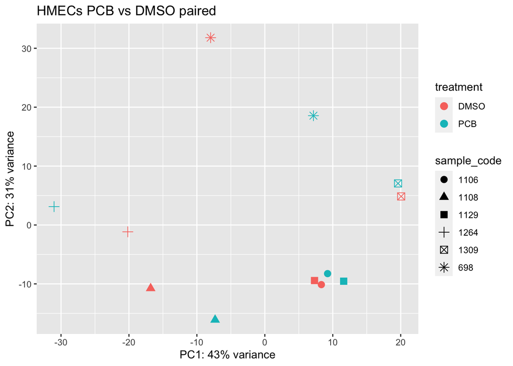

```r
p1
```

###Show the plot for the highest log2FoldChange

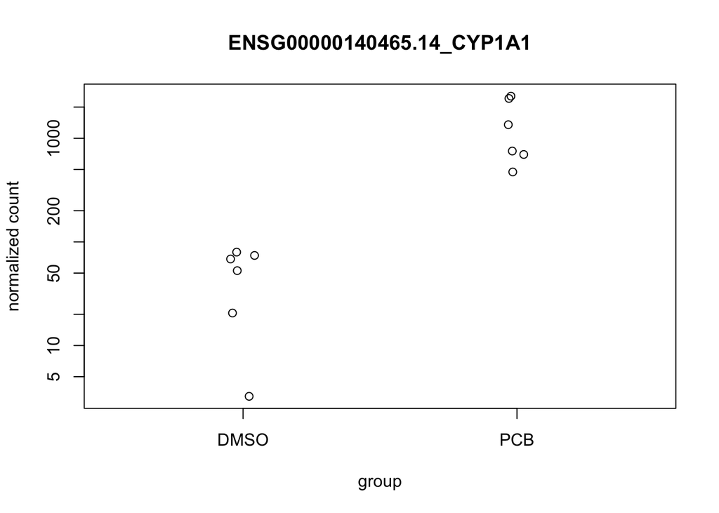

```r
plotCounts(dds1, gene= "ENSG00000140465.14_CYP1A1", intgroup="treatment")
```

###Show the highest expressing few genes

```
## [1] "res3.2"
```

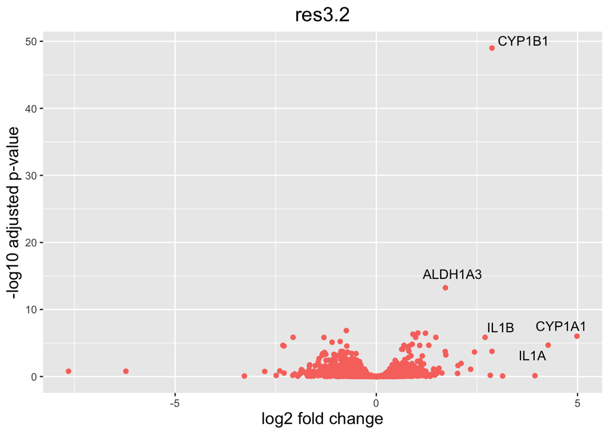

```r
plot.volcano.ggplot(res3.2, title = "HBEC PCB vs DMSO", padj = 0.01, lfc = 1)
```

###Heatmap

```r
getHeatmapDJJ <- function(dge, vsd) {
        mat <- twointersect(vsd, dge)
        mat <- assay(vsd)%>%
  as.data.frame() %>%
  rownames_to_column(var = "Gene") %>%
  filter(Gene %in% mat) %>%
  mutate(Gene = str_split(Gene, "_") %>% map_chr(., 2)) %>% column_to_rownames(var = "Gene")
        mat2 <- mat %>% t %>% scale %>% t
        mat2 <- mat2[,order(colnames(mat2), decreasing = T)]
        mat2 <- mat2[,order(unlist(map(colnames(mat2), reverse)),decreasing = T)]
        mat2treatment <- colnames(mat2) %>% str_split(., "_") %>% map_chr(., 2)
        h1 <- Heatmap(as.matrix(mat2),
              top_annotation = HeatmapAnnotation(
                treatment = mat2treatment,
                col = list(
                  treatment = c("DMSO" = "Red", "PCB" = "Green"))),
              cluster_columns = FALSE,
              show_column_dend = FALSE,
              cluster_rows = TRUE,
              show_row_names = TRUE,
              row_names_gp = gpar(fontsize = 6),
              width = unit(10, "cm"),
              height = unit(0.1 * nrow(mat2), "cm"))
return(h1)
}

#allgenes
h1 <- getHeatmapDJJ(dge = dge3.2, vsd = vsd3)
#upgegulated

dge3.2up <- dge3.2 %>% as.data.frame %>% filter(log2FoldChange > 1)
h2 <- getHeatmapDJJ(dge3.2up, vsd3)
pdf(file = "figures/Heatmap_PCB_vs_DMSO_v2.pdf", height = 11.69, width = 8.27)
h1
dev.off()
```

#TF analysis + To identify the transcription factor that might be responsible for the the expression pattern, we used the (LISA Cistrome analysis)[http://lisa.cistrome.org/]. + This takes one or two genesets as input and computes the enrichment of chromatin enrichment peaks, methylation and chromatin accessibility on these genes from publicly available dataset. + This allows the LISA Cistrome to suggest possible TFs that might be responsible for the expression pattern the provided geneset. + Following the TF analysis, we do context specific curations of the result.

```r
lisapath <- "Lisa/"
lisafiles <- list.files(lisapath, pattern = "csv")
lisanames <- lisafiles %>% str_split(".743__") %>% map_chr(2)
lisafiles <- map(paste(lisapath,lisafiles, sep = "/"), read_csv)
names(lisafiles) <- lisanames

pcb_up <- lisafiles$hg38_gs1.txt_chipseq_cauchy_combine_dedup.csv %>%
        filter(tissue %in% "Breast")
pcb_down <- lisafiles$hg38_gs2.txt_chipseq_cauchy_combine_dedup.csv %>%
        filter(tissue %in% "Breast")
pcb_tf <- full_join(pcb_up, pcb_down, by = "factor") %>%
        mutate(pval.x = ifelse(is.na(pval.x), 1, pval.x),
               pval.y = ifelse(is.na(pval.y), 1, pval.y),
               pval.xy = case_when(
                       pval.x == 1 ~ 1,
                       pval.y == 1 ~ 1,
                       TRUE ~ 0),
               pval.xy1 = case_when(
                       pval.x != 1 ~ pval.x,
                       pval.y != 1 ~ pval.y,
                       TRUE ~ 1)
               )
pcb_tf <- dge3.2geneList %>%
        rename(factor = Gene) %>%
        right_join(pcb_tf) %>%
        mutate(TFcolor = case_when(log2FoldChange > 0 ~ "#e41a1c",
                                   log2FoldChange < 0 ~ "#4daf4a",
                                   TRUE ~ "#377eb8"))

        tf1 <- ggplot(pcb_tf, aes( x = -log10(pval.x),
                        y = -log10(pval.y))) +
                geom_point(color = pcb_tf$TFcolor) +
                geom_text_repel(aes( x = -log10(pval.x),
                                     y = -log10(pval.y),
                                     label = ifelse(pval.xy == 1 & -log10(pval.xy1) > 2.5, factor, "")
                                     ))+
                geom_text_repel(aes( x = -log10(pval.x),
                                     y = -log10(pval.y),
                                     label = ifelse(!is.na(log2FoldChange), factor, ""),
                                     nudge_y = 5
                                     ))+
                 geom_text_repel(aes( x = -log10(pval.x),
                                     y = -log10(pval.y),
                                     label = ifelse(grepl("FOXM1|FOS", factor), factor, "")
                                     ))+

                labs(x = "-log10(p-value) for up-regulated gene set",
                     y = "-log10(p-value)\n for down-regulated gene set",
                     title = "Transcriptional regulators and coregulators") +
                theme_pubr() +
                theme(plot.title = element_text(face = "bold",
                                                hjust = 0.5))
pdf(file = "figures/TR_PCB_Up_Down_v2.pdf", width = 8, height = 5)
tf1
dev.off()
```

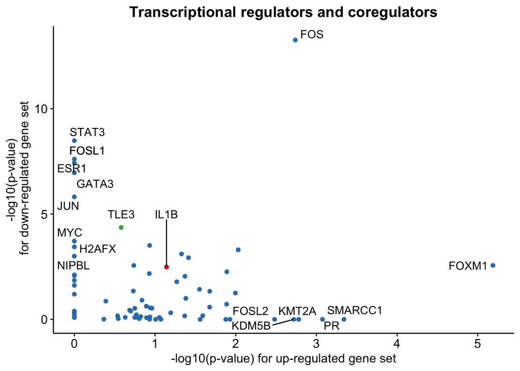

```r
tf1
```